# Script: SpatialACItaly

Michael Tiefelsdorf

3/29/2020

# 1 Import data

Import the shape-files and run basic diagnostics.

```r
setwd("G:\\UTD_Classes\\2020Spring\\GISC7360_Pattern_Analysis\\Lecture06\\Italy")
##
## Read Poly Shapefiles (readShapePoly in library maptools)
##
getinfo.shape("Provinces.shp")
```

```
## Shapefile type: Polygon, (5), # of Shapes: 95
```

```r
neig.shp <- rgdal::readOGR(dsn=getwd(), layer="Neighbors", integer64="warn.loss")
prov.shp <- rgdal::readOGR(dsn=getwd(), layer="Provinces", integer64="warn.loss")
summary(prov.shp)
```

```
## Object of class SpatialPolygonsDataFrame
## Coordinates:
##         min      max
## x  6.614898 18.52305
## y 35.490752 47.09521
## Is projected: FALSE
## proj4string :
## [+proj=longlat +datum=WGS84 +no_defs +ellps=WGS84 +towgs84=0,0,0]
## Data attributes:
##        ID            AREA          PROVID        LATCTRD
##  Min.   : 1.0   Min.   : 206   Min.   : 1.0   Min.   :36906749
##  1st Qu.:24.5   1st Qu.:2078   1st Qu.:24.5   1st Qu.:40980025
##  Median :48.0   Median :2754   Median :48.0   Median :43503625
##  Mean   :48.0   Mean   :3169   Mean   :48.0   Mean   :42881681
##  3rd Qu.:71.5   3rd Qu.:3653   3rd Qu.:71.5   3rd Qu.:45115874
##  Max.   :95.0   Max.   :7523   Max.   :95.0   Max.   :46698170
##
##     LONGCTRD        PROVNAME              REGION     RURURB     MALEPOP94
##  Min.   : 7385709   Forl\xec   : 1   Central :30   rural:86   Min.   :  44993
##  1st Qu.:10028960   Agrigento  : 1   North   :30   urban: 9   1st Qu.: 135793
##  Median :12133226   Alessandria: 1   Sardinia: 4              Median : 200644
##  Mean   :12150462   Ancona     : 1   Sicily  : 9              Mean   : 292534
##  3rd Qu.:14029612   Aosta      : 1   South   :22              3rd Qu.: 367072
##  Max.   :18178062   Arezzo     : 1                            Max.   :1886479
##                     (Other)    :89
##     FEMPOP94          TOTPOP94         POPDENSITY       TOTFERTRAT
##  Min.   :  47333   Min.   :  92326   Min.   :  35.2   Min.   :0.79
##  1st Qu.: 145345   1st Qu.: 283187   1st Qu.: 106.5   1st Qu.:1.00
##  Median : 213233   Median : 413577   Median : 165.9   Median :1.12
##  Mean   : 310293   Mean   : 602827   Mean   : 235.5   Mean   :1.18
##  3rd Qu.: 379673   3rd Qu.: 748658   3rd Qu.: 246.9   3rd Qu.:1.35
##  Max.   :2028089   Max.   :3914568   Max.   :2620.1   Max.   :1.73
##
##    FEMMARAGE       DIVORCERAT       ILLITERRAT      TELEPERFAM
##  Min.   :24.62   Min.   :0.0500   Min.   :0.240   Min.   :0.4585
##  1st Qu.:26.18   1st Qu.:0.2150   1st Qu.:0.715   1st Qu.:0.7327
##  Median :26.93   Median :0.3900   Median :1.580   Median :0.7907
##  Mean   :26.72   Mean   :0.4395   Mean   :2.292   Mean   :0.7666
##  3rd Qu.:27.25   3rd Qu.:0.6600   3rd Qu.:3.505   3rd Qu.:0.8241
##  Max.   :28.42   Max.   :1.0600   Max.   :7.420   Max.   :0.8919
##
```

```r
proj4string(prov.shp)                                    # map projection
```

```
## [1] "+proj=longlat +datum=WGS84 +no_defs +ellps=WGS84 +towgs84=0,0,0"
```

```r
prov.centroid <- coordinates(prov.shp)                   # Get province centroids
prov.bbox <- bbox(prov.shp)                              # province bounding box for map region
```

# 2 Gradient map of `TOTFERTRAT` and bi-polar map of `lm(TOTFERTRAT~1)`

Gradient map:

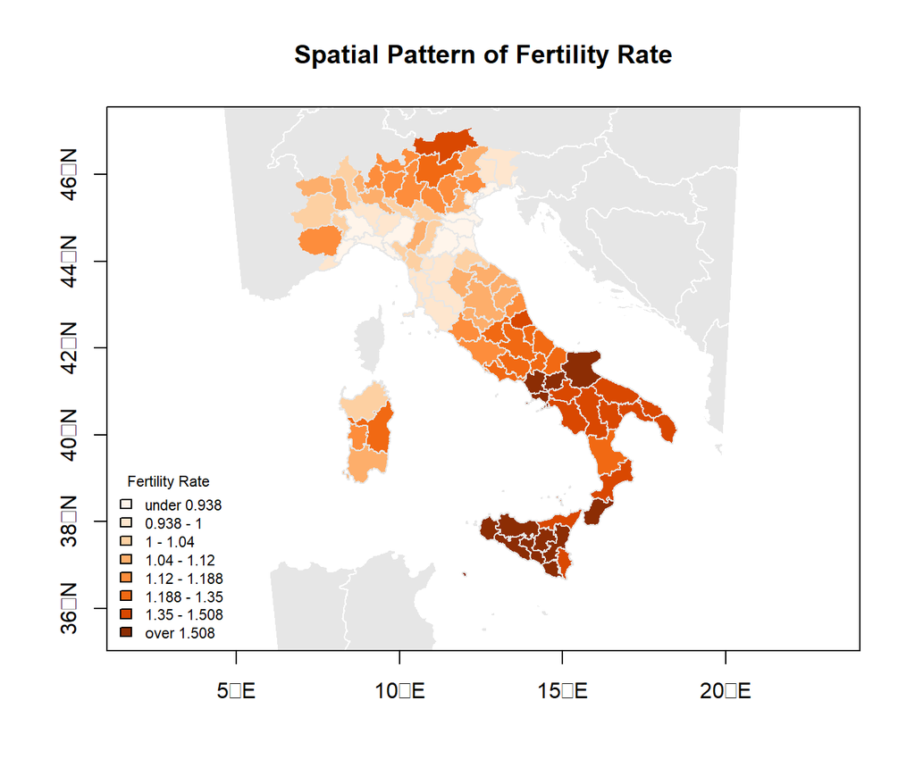

```r
plot(neig.shp,axes=T,col=grey(0.9),border="white",       # first background (axes=T adds lat/long frame)
     xlim=prov.bbox[1,],ylim=prov.bbox[2,])              # within bounding box
mapColorRamp(prov.shp$TOTFERTRAT, prov.shp, breaks=8,    # second add map
              map.title="Spatial Pattern of Fertility Rate",
              legend.title="Fertility Rate",
              legend.cex=0.7, add.to.map=T)
```

Mapping the variation around the mean is more appropriate:

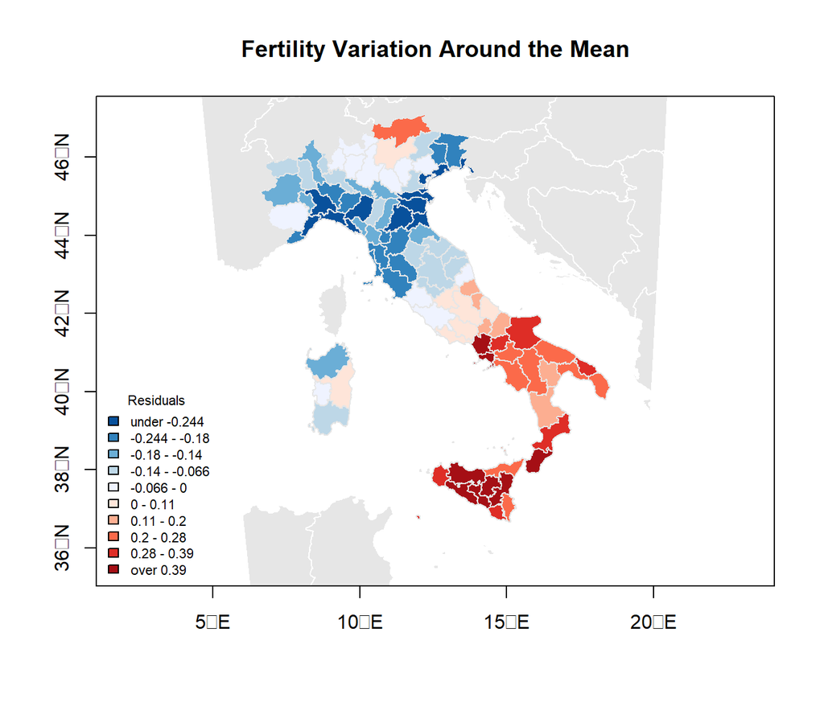

```r
varMean <- residuals(lm(TOTFERTRAT~1, data=prov.shp))
plot(neig.shp,axes=T,col=grey(0.9),border="white",
     xlim=prov.bbox[1,],ylim=prov.bbox[2,])               # first background
mapBiPolar(varMean, prov.shp,                             # second regression residuals
            neg.breaks=5, pos.breaks=5, break.value=0.0,
            map.title="Fertility Variation Around the Mean",
            legend.title="Residuals",
            legend.cex=0.7, add.to.map=T)
```

# 3 Basic regression model

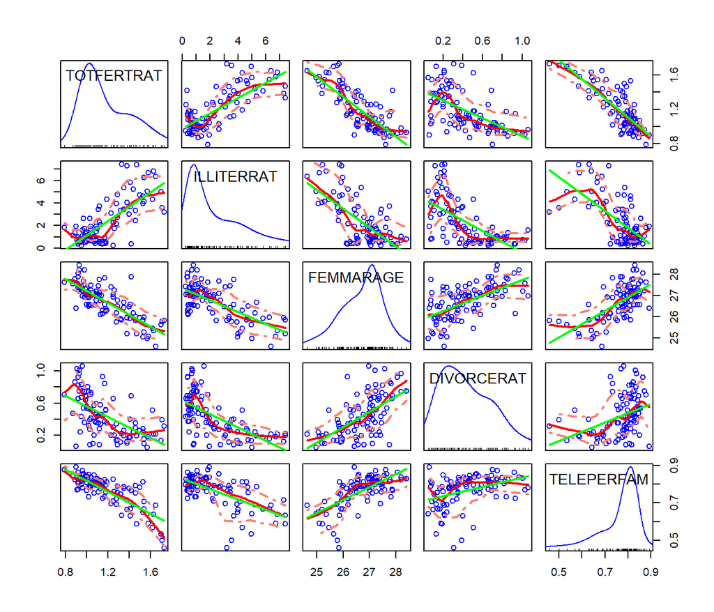

```r
## Regression model for fertility including model diagnostics
scatterplotMatrix(~TOTFERTRAT+ILLITERRAT+FEMMARAGE+DIVORCERAT+TELEPERFAM, data=prov.shp,
                   smooth=list(span = 0.35, lty.smooth=1, col.smooth="red", col.var="salmon"),
                   regLine=list(col="green"))
```

```r
fert.lm <- lm(TOTFERTRAT~ILLITERRAT+FEMMARAGE+DIVORCERAT+TELEPERFAM, data=prov.shp)
summary(fert.lm,corr=F)
```

```
##
## Call:
## lm(formula = TOTFERTRAT ~ ILLITERRAT + FEMMARAGE + DIVORCERAT +
##     TELEPERFAM, data = prov.shp)
##
## Residuals:
##      Min       1Q   Median       3Q      Max
## -0.21906 -0.06267 -0.00966  0.05425  0.41272
##
## Coefficients:
##              Estimate Std. Error t value Pr(>|t|)
## (Intercept)  4.496337   0.513726   8.752 1.13e-13 ***
## ILLITERRAT   0.020377   0.008735   2.333   0.0219 *
## FEMMARAGE   -0.088837   0.020771  -4.277 4.71e-05 ***
## DIVORCERAT  -0.112265   0.055648  -2.017   0.0466 *
## TELEPERFAM  -1.226364   0.183037  -6.700 1.76e-09 ***
## ---
## Signif. codes:  0 '***' 0.001 '**' 0.01 '*' 0.05 '.' 0.1 ' ' 1
##
## Residual standard error: 0.1035 on 90 degrees of freedom
## Multiple R-squared:  0.8096, Adjusted R-squared:  0.8012
## F-statistic: 95.69 on 4 and 90 DF,  p-value: < 2.2e-16
```

```r
vif(fert.lm)
```

```
## ILLITERRAT  FEMMARAGE DIVORCERAT TELEPERFAM
##   2.601115   2.468365   1.855334   2.088907
```

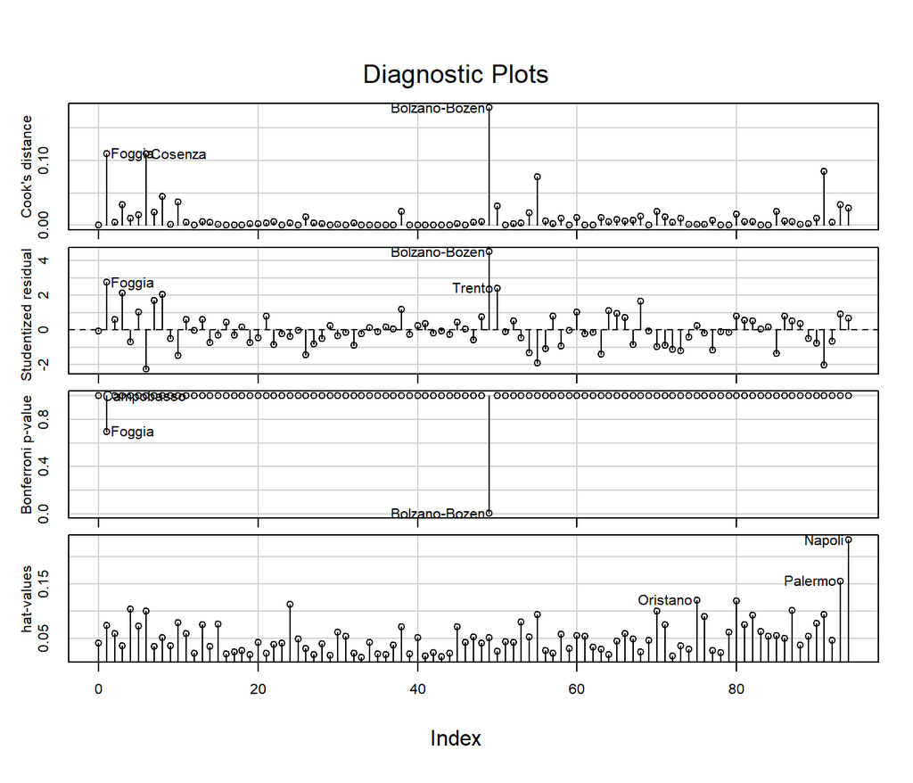

```r
# Perform Residual Diagnostics
influenceIndexPlot(fert.lm, id=list(n=3,labels=prov.shp$PROVNAME))
```

```r
fertResid <- residuals(fert.lm)
```

# 4 Identify potential outliers

```r
## Why is Bolzano-Bozen an extreme observation? Shall we delete it?
idx.max <- which.max(abs(fertResid))        # Get index of a record with "outlying" observation

## Map potential outlier
extremeObs <- rep(0, length(fertResid))
extremeObs[idx.max] <- 1
extremeObs <- factor(extremeObs, labels=c("Population","Outlier"))
table(extremeObs)
```

```
## extremeObs
## Population    Outlier
##         94          1
```

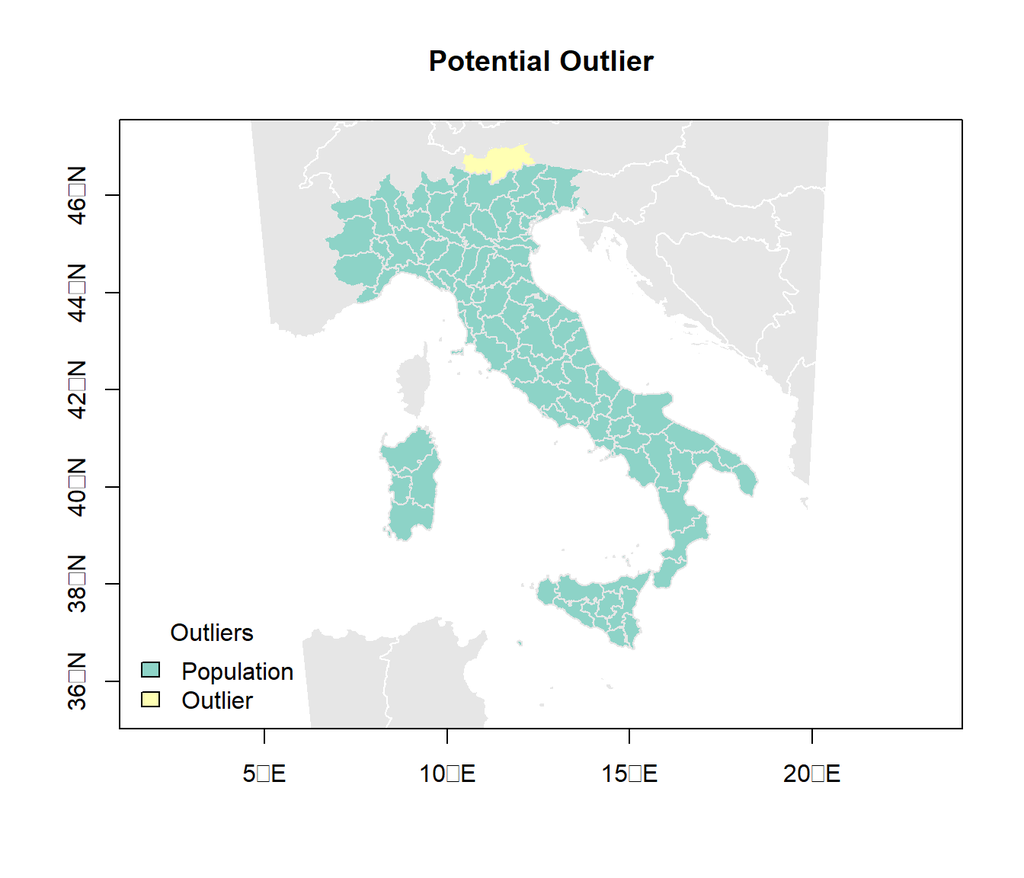

```r
plot(neig.shp,axes=T,col=grey(0.9),border="white",                 # background: neighboring countries
     xlim=prov.bbox[1,],ylim=prov.bbox[2,])
mapColorQual(extremeObs, prov.shp, map.title="Potential Outlier",
              legend.title="Outliers", add.to.map=T)
```

```r
## Inspect outlier
prov.shp@data[idx.max,]                      # List info of record centre is outlier
```

```
##    ID     AREA PROVID  LATCTRD LONGCTRD      PROVNAME REGION RURURB MALEPOP94
## 49 50 7466.006     21 46698170 11414936 Bolzano-Bozen  North  rural    220787
##    FEMPOP94 TOTPOP94 POPDENSITY TOTFERTRAT FEMMARAGE DIVORCERAT ILLITERRAT
## 49   228268   449055   60.14662       1.42     27.88       0.69       0.35
##    TELEPERFAM
## 49    0.76808
```

```r
## Delete outlier or update information
#prov.shp <- prov.shp[-idx.max ]             # Delete extreme observation from shapefile
prov.shp@data[idx.max, "TOTFERTRAT"] <- 1.2  # Or change its value within the shapefile

## Continue with updated dataset
fert.lm <- lm(TOTFERTRAT~ILLITERRAT+FEMMARAGE+DIVORCERAT+TELEPERFAM,data=prov.shp) # update model
summary(fert.lm)
```

```
##
## Call:
## lm(formula = TOTFERTRAT ~ ILLITERRAT + FEMMARAGE + DIVORCERAT +
##     TELEPERFAM, data = prov.shp)
##
## Residuals:
##       Min        1Q    Median        3Q       Max
## -0.219546 -0.059570 -0.008288  0.055215  0.256479
##
## Coefficients:
##              Estimate Std. Error t value Pr(>|t|)
## (Intercept)  4.625004   0.476205   9.712 1.13e-15 ***
## ILLITERRAT   0.021280   0.008097   2.628   0.0101 *
## FEMMARAGE   -0.095354   0.019254  -4.953 3.41e-06 ***
## DIVORCERAT  -0.111163   0.051584  -2.155   0.0338 *
## TELEPERFAM  -1.173424   0.169668  -6.916 6.54e-10 ***
## ---
## Signif. codes:  0 '***' 0.001 '**' 0.01 '*' 0.05 '.' 0.1 ' ' 1
##
## Residual standard error: 0.09594 on 90 degrees of freedom
## Multiple R-squared:  0.8345, Adjusted R-squared:  0.8272
## F-statistic: 113.5 on 4 and 90 DF,  p-value: < 2.2e-16
```

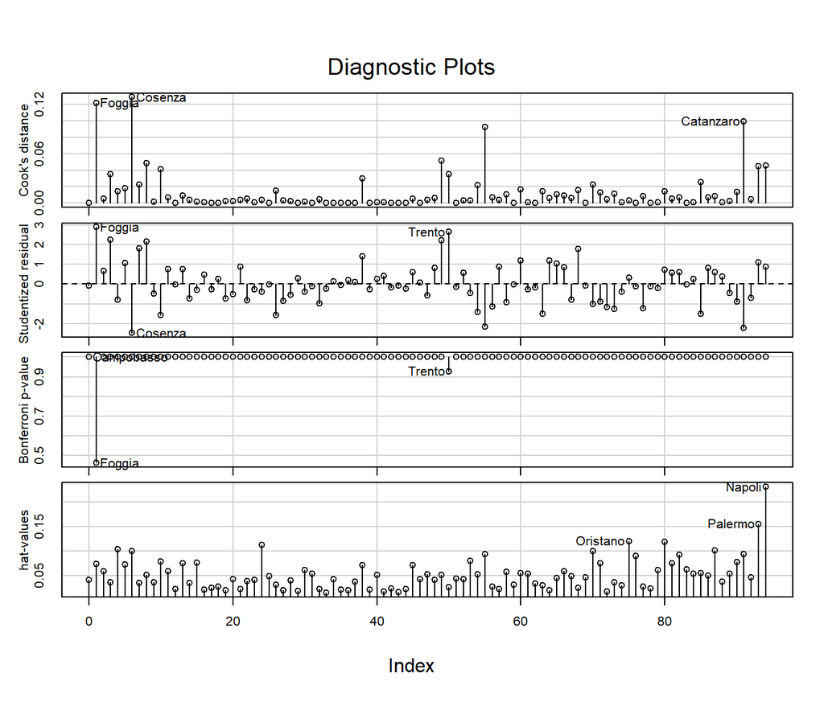

```r
influenceIndexPlot(fert.lm, id=list(n=3, labels=prov.shp$PROVNAME))
```

# 5 Check for heteroscedasticity

```r
## Check for heteroscedasticity
fert.fgls <- lmHetero(TOTFERTRAT~ILLITERRAT+FEMMARAGE+DIVORCERAT+TELEPERFAM | log(FEMPOP94),
                      data=prov.shp)
summary(fert.fgls)
```

```
##
## ================================================================
## Multiplicatively Weighted Heteroscedasticity ML-Regression Model
## ================================================================
##
## Call:
## lmHetero(formula = TOTFERTRAT ~ ILLITERRAT + FEMMARAGE + DIVORCERAT +
##     TELEPERFAM | log(FEMPOP94), data = prov.shp)
##
## Regression Coefficients:
##               Estimate    Std.Err z-value  Pr(>|z|)
## (Intercept)  4.3881835  0.4265870 10.2867 < 2.2e-16 ***
## ILLITERRAT   0.0286213  0.0074558  3.8388 0.0001236 ***
## FEMMARAGE   -0.0894065  0.0174198 -5.1325 2.860e-07 ***
## DIVORCERAT  -0.1073668  0.0441414 -2.4323 0.0150017 *
## TELEPERFAM  -1.1055990  0.1775114 -6.2283 4.714e-10 ***
## ---
## Signif. codes:  0 '***' 0.001 '**' 0.01 '*' 0.05 '.' 0.1 ' ' 1
##
## Gamma Coefficients:
##                   Gamma   Std.Err z-value  Pr(>|z|)
## (Intercept)   -12.60936   2.56690 -4.9123 9.001e-07 ***
## log(FEMPOP94)   0.63263   0.20748  3.0492  0.002295 **
## ---
## Signif. codes:  0 '***' 0.001 '**' 0.01 '*' 0.05 '.' 0.1 ' ' 1
##
## log-likelihood = 92.96326
##
## Heteroscedasticity likelihood ratio test:
##        LR   df  Pr(Chi > LR)
##  5.019431    1    0.02506441
```

Note the positive sign of $\gamma_2$ is contradicting theory. This is marginal significant of the heteroscedastic model and will be used subsequently for demonstration purposes.

Therefore, the lm-model is updated to a weighted lm-model.

```r
fert.wlm <- lm(TOTFERTRAT~ILLITERRAT+FEMMARAGE+DIVORCERAT+TELEPERFAM, data=prov.shp,
               weights=fert.fgls$weights)
```

# 6 Bipolar map theme of regression residual

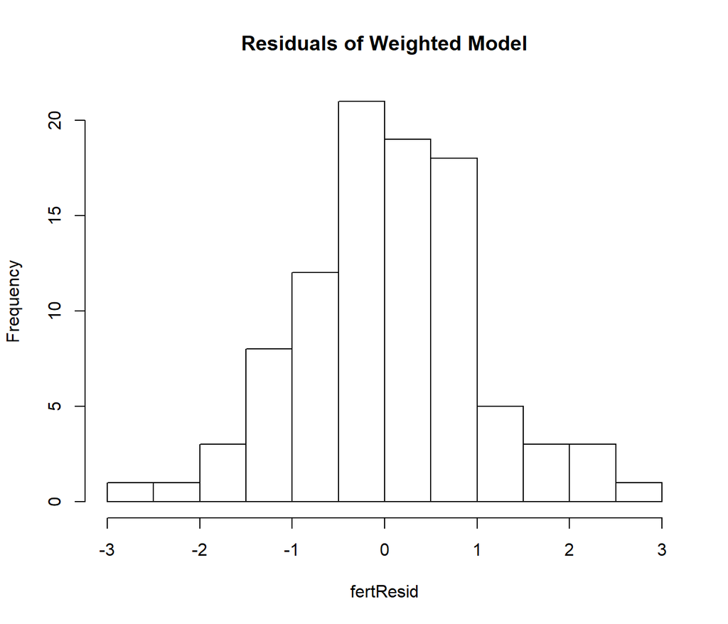

```r
## Plot Regression Residuals (Bi-polar)
fertResid <- weighted.residuals(fert.wlm)                # Update residuals
hist(fertResid, main="Residuals of Weighted Model")      # Explore distribution to
```

```r
length(fertResid[fertResid < 0])                         # identify number of pos/neg classes
```

```
## [1] 46
```

```r
length(fertResid[fertResid >= 0])
```

```
## [1] 49
```

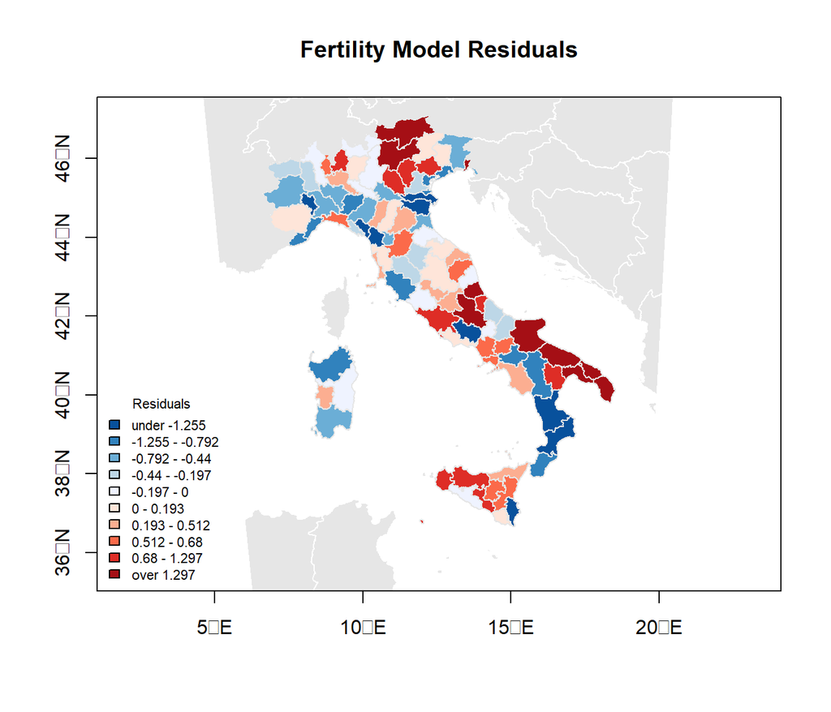

```r
plot(neig.shp,axes=T,col=grey(0.9),border="white",
     xlim=prov.bbox[1,],ylim=prov.bbox[2,])               # first background
mapBiPolar(fertResid, prov.shp,                           # second regression residuals
            neg.breaks=5, pos.breaks=5, break.value=0.0,
            map.title="Fertility Model Residuals",
            legend.title="Residuals",
            legend.cex=0.7, add.to.map=T)
```

The map pattern indicates that there are spatial clusters with positive and negative regression residuals. Thus the independence assumption is violated.

# 7 Identify the linkage structure

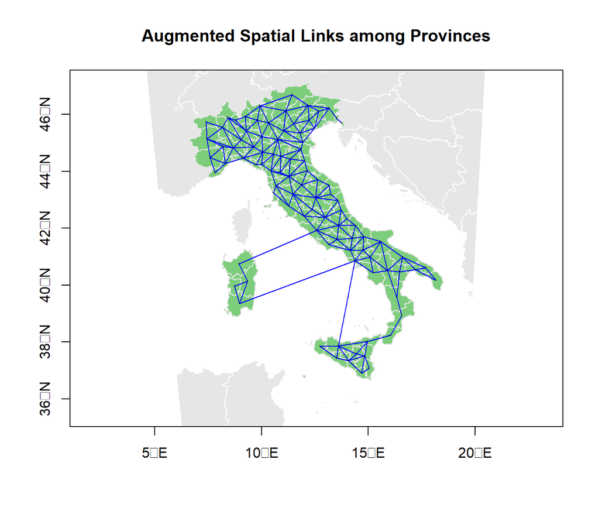

```r
## Plot Augmented Spatial Links among Italian Provinces
## Notes: Shape file has been edited so satellite islands are connected to mainland
## Alternatively spdep::edit.nb function (does not work with RStudio)
prov.link <- poly2nb(prov.shp, queen=F)                          # Generate neighbors links

plot(neig.shp,axes=T,col=grey(0.9),border="white",
     xlim=prov.bbox[1,],ylim=prov.bbox[2,])                      # First background
plot(prov.shp,col="palegreen3" ,border=grey(0.9), axes=T, add=T) # Second plot areas
plot(prov.link,coords=prov.centroid, pch=19, cex=0.1,            # Third plot links focused at centroids
     col="blue", add=T)
title("Augmented Spatial Links among Provinces")                 # Forth add title
box()                                                            # Fifth refresh frame
```

Explore the structure of `prov.link`:

```r
summary(prov.link)
```

```
## Neighbour list object:
## Number of regions: 95
## Number of nonzero links: 424
## Percentage nonzero weights: 4.698061
## Average number of links: 4.463158
## Link number distribution:
##
##  1  2  3  4  5  6  7  8
##  1 11 14 20 27 13  6  3
## 1 least connected region:
## 67 with 1 link
## 3 most connected regions:
## 11 28 35 with 8 links
```

```r
str(prov.link)
```

```
## List of 95
##  $ : int [1:5] 2 3 62 63 88
##  $ : int [1:5] 1 3 4 5 93
##  $ : int [1:5] 1 2 88 93 95
##  $ : int [1:5] 2 5 6 8 9
##  $ : int [1:6] 2 4 6 7 89 93
##  $ : int [1:4] 4 5 7 8
##  $ : int [1:3] 5 6 92
##  $ : int [1:4] 4 6 9 69
##  $ : int [1:3] 4 8 69
##  $ : int [1:4] 11 12 46 47
##  $ : int [1:6] 10 12 13 27 30 47
##  $ : int [1:8] 10 11 13 32 40 45 46 48
##  $ : int [1:5] 11 12 32 33 35
##  $ : int [1:5] 15 16 23 28 72
```

[output cut: 86 more lines]

# 8 Perform a test for spatial autocorrelation in the residuals

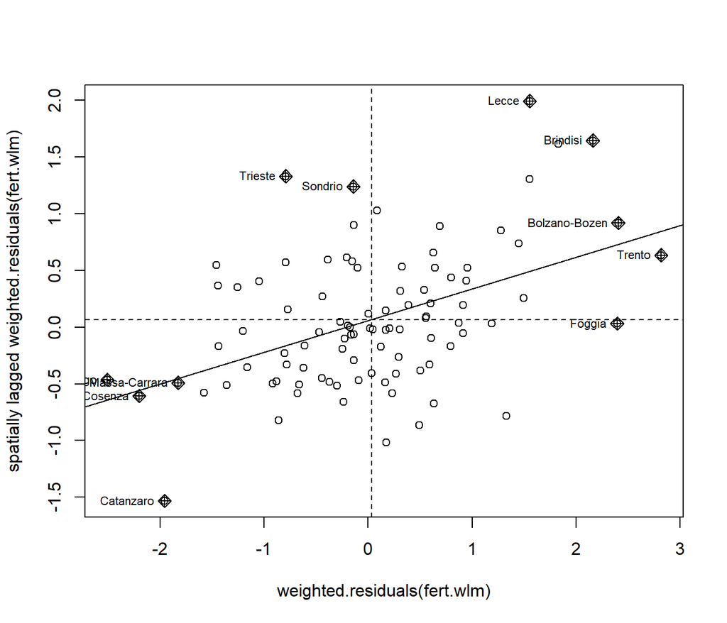

```r
prov.linkW <- nb2listw(prov.link, style="W")                   # generated row-sum standardized neighbors list
spOutliers <- moran.plot(weighted.residuals(fert.wlm),         # Moran plot with outlier diagnositics
                         prov.linkW, labels=prov.shp$PROVNAME)
```

```r
lm.morantest(fert.wlm, prov.linkW)                             # Test with W-coding scheme
```

```
##
##  Global Moran I for regression residuals
##
## data:
## model: lm(formula = TOTFERTRAT ~ ILLITERRAT + FEMMARAGE + DIVORCERAT +
## TELEPERFAM, data = prov.shp, weights = fert.fgls$weights)
## weights: prov.linkW
##
## Moran I statistic standard deviate = 4.5306, p-value = 2.941e-06
## alternative hypothesis: greater
## sample estimates:
## Observed Moran I      Expectation         Variance
##      0.281242173     -0.029598120      0.004707174
```

Also look up `help(lm.morantest)`. Internally weighted regression residuals are used.

# 9 Evaluate Correlogram (correlation at higher order spatial lags)

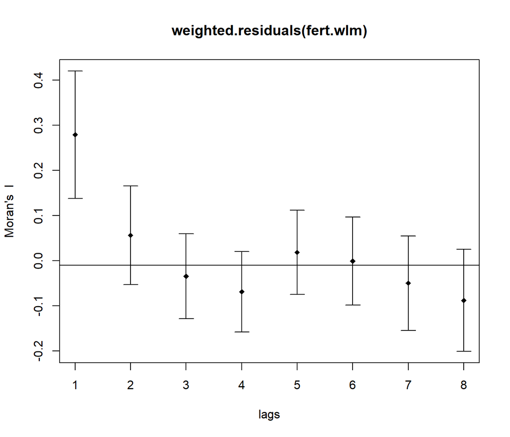

```r
plot(sp.correlogram(prov.link, weighted.residuals(fert.wlm), order=8, method="I", style = "W"))
```

From spatial lag 2 onward Moran’s I is no longer significant.

# 10 Test for Spatial Autocorrelation Using Randomization

In case the assumption that the residuals are normally distributed no longer holds, the distribution of Morans’s $I$ can evaluated using a randomization approach.

```r
moran.mc(weighted.residuals(fert.wlm), prov.linkW, nsim=9999)
```

```
##
##  Monte-Carlo simulation of Moran I
##
## data:  weighted.residuals(fert.wlm)
## weights: prov.linkW
## number of simulations + 1: 10000
##
## statistic = 0.2792, observed rank = 9997, p-value = 3e-04
## alternative hypothesis: greater
```

```r
help(moran.mc, package="spdep")
```

```
## starting httpd help server ... done
```

A few examples of random pattern:

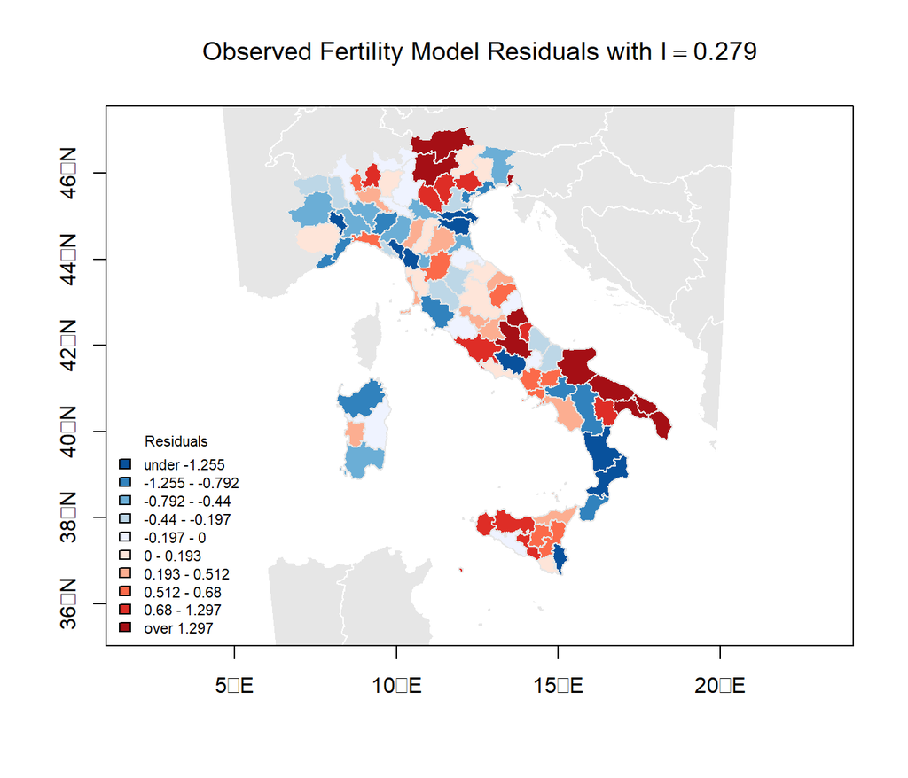

```r
##
## Evaluation by randomization
##
fertResid <- weighted.residuals(fert.wlm)

## Original values
mi <- lm.morantest(lm(fertResid~1), prov.linkW)           # Test with W-coding scheme
plot(neig.shp,axes=T,col=grey(0.9),border="white",
     xlim=prov.bbox[1,],ylim=prov.bbox[2,])               # first background
mapBiPolar(fertResid, prov.shp,                           # second regression residuals
           neg.breaks=5, pos.breaks=5, break.value=0.0,
           map.title="",
           legend.title="Residuals",
           legend.cex=0.7, add.to.map=T)
title(main=bquote(paste("Observed Fertility Model Residuals with ", I==.(round(mi$estimate[[1]],3)))),
      cex.main=1.2)
```

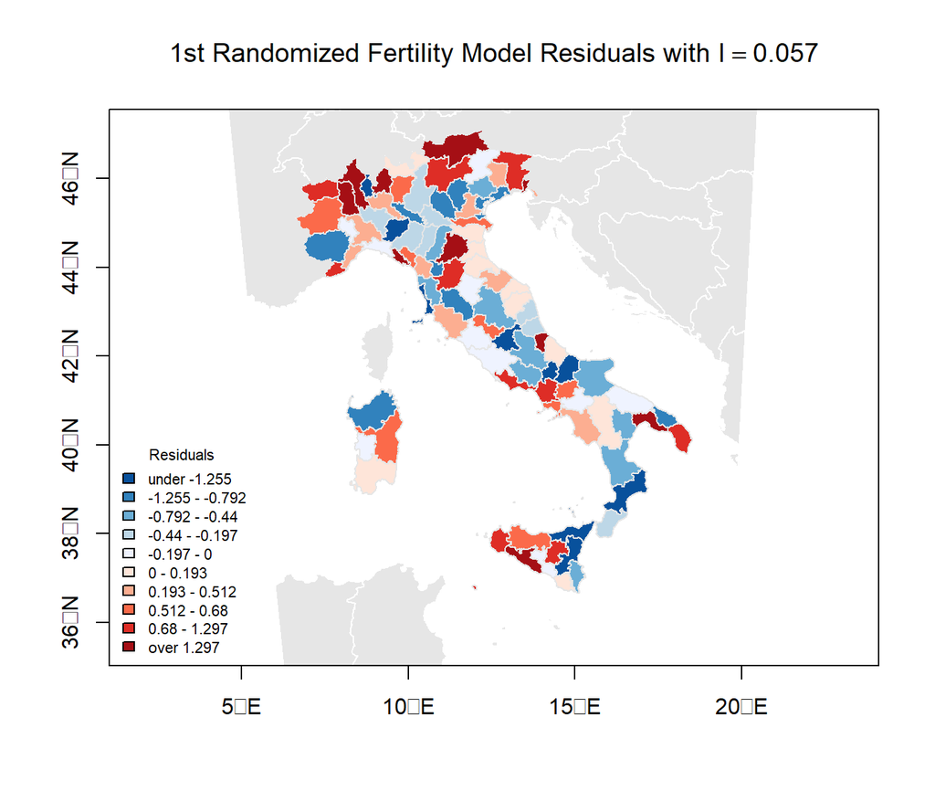

```r
## 1st Randomization
fertResid <- sample(fertResid, size=length(fertResid))
mi <- lm.morantest(lm(fertResid~1), prov.linkW)           # Test with W-coding scheme
plot(neig.shp,axes=T,col=grey(0.9),border="white",
     xlim=prov.bbox[1,],ylim=prov.bbox[2,])               # first background
mapBiPolar(fertResid, prov.shp,                           # second regression residuals
           neg.breaks=5, pos.breaks=5, break.value=0.0,
           map.title="",
           legend.title="Residuals",
           legend.cex=0.7, add.to.map=T)
title(main=bquote(paste("1st Randomized Fertility Model Residuals with ", I==.(round(mi$estimate[[1]],3)))),
      cex.main=1.2)
```

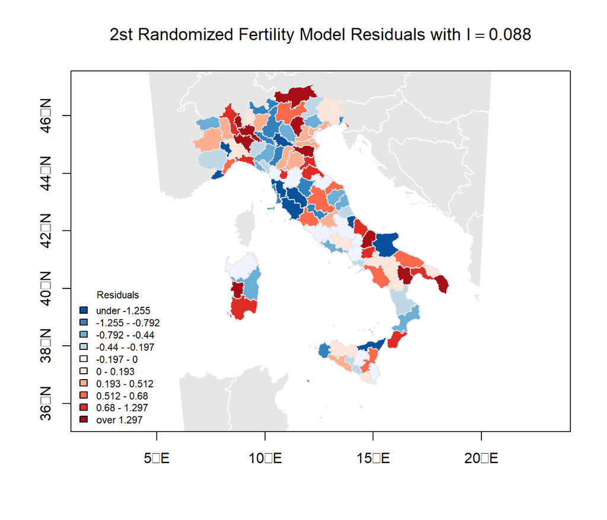

```r
## 2nd Randomization
fertResid <- sample(fertResid, size=length(fertResid))
mi <- lm.morantest(lm(fertResid~1), prov.linkW)           # Test with W-coding scheme
plot(neig.shp,axes=T,col=grey(0.9),border="white",
     xlim=prov.bbox[1,],ylim=prov.bbox[2,])               # first background
mapBiPolar(fertResid, prov.shp,                           # second regression residuals
           neg.breaks=5, pos.breaks=5, break.value=0.0,
           map.title="",
           legend.title="Residuals",
           legend.cex=0.7, add.to.map=T)
title(main=bquote(paste("2st Randomized Fertility Model Residuals with ", I==.(round(mi$estimate[[1]],3)))),
      cex.main=1.2)
```

# 11 Eigenvalues and Vectors of Spatial Link Matrix

The two most extreme spatial patterns of $\bf{M} \cdot (\bf{V}+\bf{V}^T)/2 \cdot \bf{M}$ are shown below

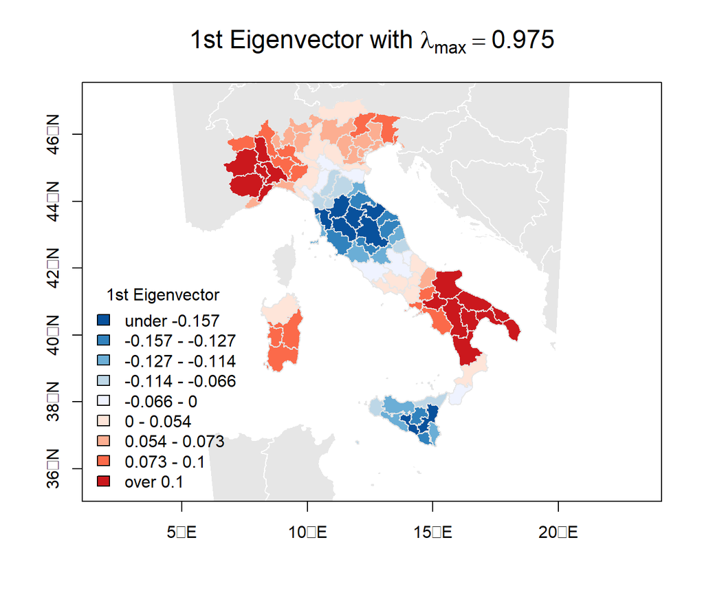

```r
V <- spdep::nb2mat(prov.link, style="W", zero.policy = TRUE)
X <- model.matrix(fert.wlm)                               # design matrix
n <- nrow(X)
M <- diag(1,nrow=n) - X %*% solve(t(X)%*%X) %*% t(X)      # projection matrix
MVM <- M %*% ((V+t(V))*0.5) %*% M
eig <- eigen(MVM, symmetric = T)                          # list of eigen values and vectors

# First eigenvector
plot(neig.shp,axes=T,col=grey(0.9),border="white",
     xlim=prov.bbox[1,],ylim=prov.bbox[2,])               # first background
mapBiPolar(eig$vectors[,1], prov.shp,
           neg.breaks=5, pos.breaks=4, break.value=0.0,
           map.title="",
           legend.title="1st Eigenvector",
           legend.cex=1, add.to.map=T)
title(main=bquote(paste("1st Eigenvector with ", lambda[max] == .(round(eig$values[1],3)))),
      cex.main=1.5)
```

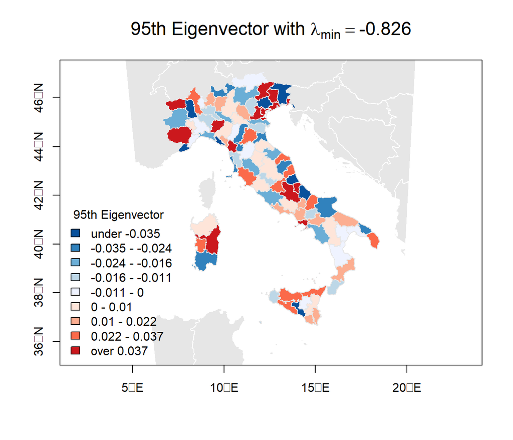

```r
# Last eigenvector
plot(neig.shp,axes=T,col=grey(0.9),border="white",
     xlim=prov.bbox[1,],ylim=prov.bbox[2,])               # first background
mapBiPolar(eig$vectors[,n], prov.shp,
           neg.breaks=5, pos.breaks=4, break.value=0.0,
           map.title="",
           legend.title="95th Eigenvector",
           legend.cex=1, add.to.map=T)
title(main=bquote(paste("95th Eigenvector with ", lambda[min] == .(round(eig$values[n],3)))),
      cex.main=1.5)
```

# 12 Local Moran’s $I_i$

## 12.1 Helper function

Overlays point symbols onto of choropleth map indicating the significance of local Moran’s $I_i$.

```r
mapProbsAdd <- function(var.prob, shape, leg.title=expression(Pr(I[i] <= I[i]^"obs" , H[0])),
                        legend.pos="bottomright", legend.cex=1, symbol.cex=1) {
  require(spdep); require(classInt)
  prob.breaks <- c(0.00,0.01,0.05,0.50,0.95,0.99,1.00)
  prob.cex <- c(1.2,0.9,0.7,0.7,0.9,1.2)*symbol.cex
  prob.col <- rev(c("#D53E4F","#FC8D59","#FEE08B","#E6F598","#99D594","#3288BD"))
  prob.shape <- c(25,25,25,24,24,24)

  cnt <- coordinates(shape)

  sym.cex <- prob.cex[findInterval(var.prob,prob.breaks,rightmost.closed=T)]
  sym.col <- prob.col[findInterval(var.prob,prob.breaks,rightmost.closed=T)]
  sym.shape <- prob.shape[findInterval(var.prob,prob.breaks,rightmost.closed=T)]

  points(cnt, pch=sym.shape, col=grey(0.7), bg=sym.col, cex=sym.cex)

  legend(legend.pos, legend= leglabs(prob.breaks), cex = legend.cex,
         pch=prob.shape, pt.bg=prob.col, pt.cex=prob.cex,
         col=grey(0.7), bty="n", title=leg.title)
  box()
} #end::mapProbs
```

## 12.2 Local Moran’s $I_i$ cumulative probability

Since there is global positive autocorrelation in the residuals, we will have many local clusters exhibiting positive local autocorrelation.

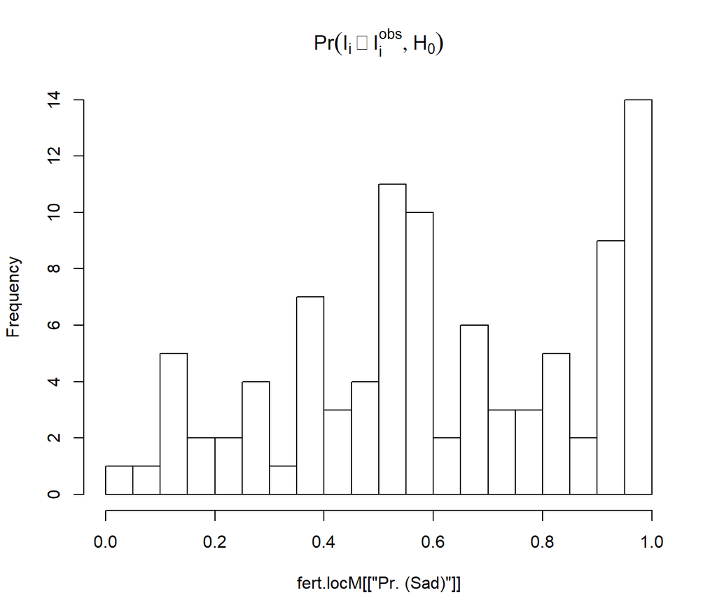

```r
fert.locM <- summary(localmoran.sad(fert.wlm, prov.link, style="W", resfun=weighted.residuals,
                                   alternative="less", select=seq_along(prov.shp)))
hist(fert.locM[["Pr. (Sad)"]], main=expression(Pr(I[i] <= I[i]^"obs" , H[0])), nclass=20)
```

```r
head(fert.locM)
```

```
##     Local Morans I Stand. dev. (N)   Pr. (N) Saddlepoint Pr. (Sad) Expectation
## 1 0    -0.12463786      -0.2162566 0.4143939  -0.4140175 0.3394307 -0.03374134
## 2 1     0.07411736       0.2622125 0.6034212   0.3679656 0.6435506 -0.03177174
## 3 2     0.33545615       0.8924035 0.8139117   1.1351831 0.8718507 -0.04077257
## 4 3     2.02930364       5.0234005 0.9999997   3.1923864 0.9992945 -0.02247407
## 5 4    -0.42129263      -0.9863691 0.1619760  -1.1645874 0.1220930 -0.05892191
## 6 5     0.03957225       0.1795681 0.5712542   0.2167110 0.5857832 -0.04446989
##      Variance   Skewness Kurtosis   Minimum  Maximum        omega      sad.r
## 1 0 0.1766671 -0.4490366 8.388376 -20.58264 17.54592 -0.005141048 -0.2085238
## 2 1 0.1630782 -0.4401614 8.383262 -19.74838 16.88893  0.007027691  0.2603288
## 3 2 0.1777384 -0.5399528 8.446700 -20.92997 17.26044  0.017459528  0.8283320
## 4 3 0.1668265 -0.3084653 8.319445 -19.56748 17.54482  0.029269940  2.8820979
## 5 4 0.1349669 -0.8859394 8.768715 -19.15928 13.85631 -0.015908165 -0.7996510
## 6 5 0.2190463 -0.5306011 8.440201 -23.20280 19.20051  0.004250279  0.1791867
##          sad.u
## 1 0 -0.2176534
## 2 1  0.2677267
## 3 2  1.0680487
## 4 3  7.0483966
## 5 4 -1.0706242
## 6 5  0.1803956
```

## 12.3 Interpretation of local Moran’s $I_i$

Local Moran’s $I_i$ can best interpreted in combination with the associated residual pattern. Only then can we identify significant:

- spatial clusters in positive residuals
- spatial clusters in negative residuals
- spatial hot spots of a negative residual surrounded by positive residuals
- spatial hot spots of a positive residual surrounded by negative residuals

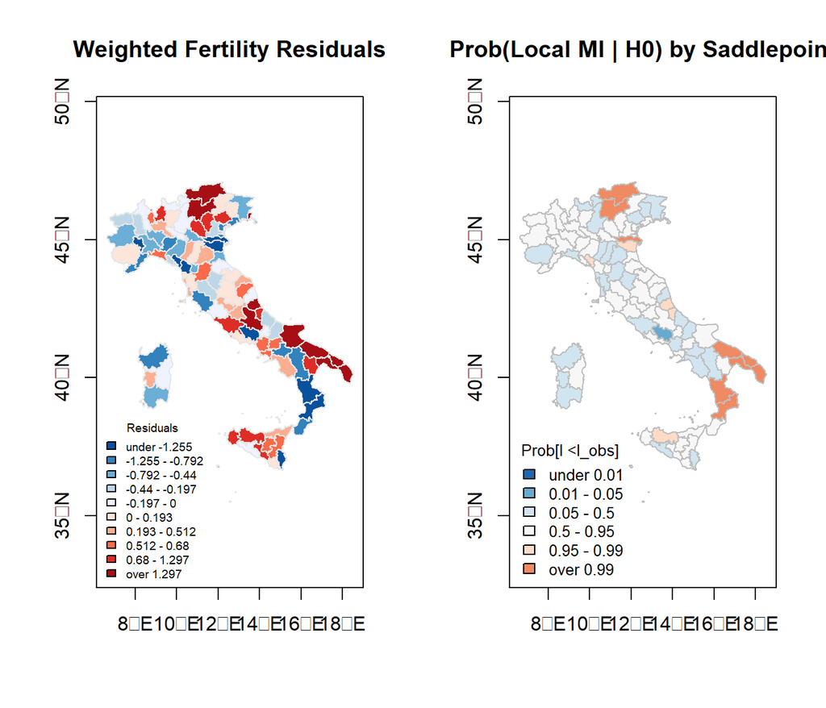

```r
##
## Map residuals and cummulative Moran's probabilities
##
layout(matrix(c(1,2),ncol = 2))
  mapBiPolar(weighted.residuals(fert.wlm), prov.shp, neg.breaks=5, pos.breaks=5, break.value=0,
              map.title="Weighted Fertility Residuals", legend.title="Residuals", legend.cex = 0.6,
              add.to.map=F)

  cumProbs <- c(0,0.01,0.05,0.5,0.95,0.99,1)
  ncl <- length( cumProbs)
  pal <- rev(RColorBrewer::brewer.pal(ncl,"RdBu"))
  cols <- pal[findInterval(fert.locM[["Pr. (Sad)"]], cumProbs, rightmost.closed=T)]
  sp::plot(prov.shp, col=cols, border="grey", main="Prob(Local MI | H0) by Saddlepoint", axes=TRUE)
  legend("bottomleft", legend=leglabs(round(cumProbs,digits=2)), fill=pal, bty="n", cex=0.8,
         title="Prob[I <I_obs]")
  box()
```

```r
layout(1)
```

## 12.4 Zooming and alternative significance mapping

This snippet demonstrate that the bounding box controls the mapped area. Thus changing its parameters enables us to zoom in R maps.

A bipolar map theme of triangles is overlaid onto top of the residual map to identify significant clusters and hot spots.

```r
## Experimental Map with local MI significances zoomed into northern Italy
(zoom <- bbox(prov.shp))
```

```
##         min      max
## x  6.614898 18.52305
## y 35.490752 47.09521
```

```r
zoom[1,2] <- 16
zoom[2,1] <- 42
zoom
```

```
##         min      max
## x  6.614898 16.00000
## y 42.000000 47.09521
```

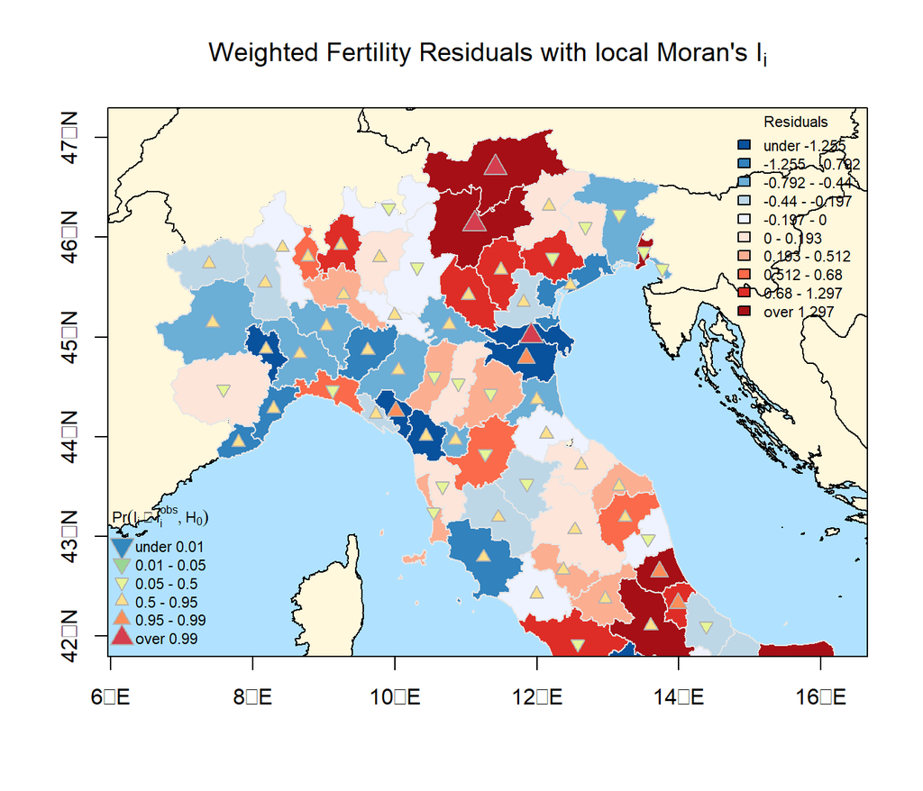

```r
plot(neig.shp, col="cornsilk", axes=T, xlim=zoom[1,], ylim=zoom[2,], bg="lightskyblue1")
mapBiPolar(weighted.residuals(fert.wlm), prov.shp, neg.breaks=5, pos.breaks=5, break.value=0,
           map.title=expression(paste("Weighted Fertility Residuals with local Moran's ", I[i])),
           legend.title="Residuals", legend.cex= 0.7, legend.pos="topright", add.to.map=T)
mapProbsAdd(fert.locM[["Pr. (Sad)"]], prov.shp, legend.pos="bottomleft",        # Add significance symbols
            legend.cex=0.7, symbol.cex=1.5)
```

## Variance of local Moran’s $I_i$ by coding scheme The variances of local Moran’s $I_i$ indicate how influential a particular region is on the global Moran’s $I$ statistic.

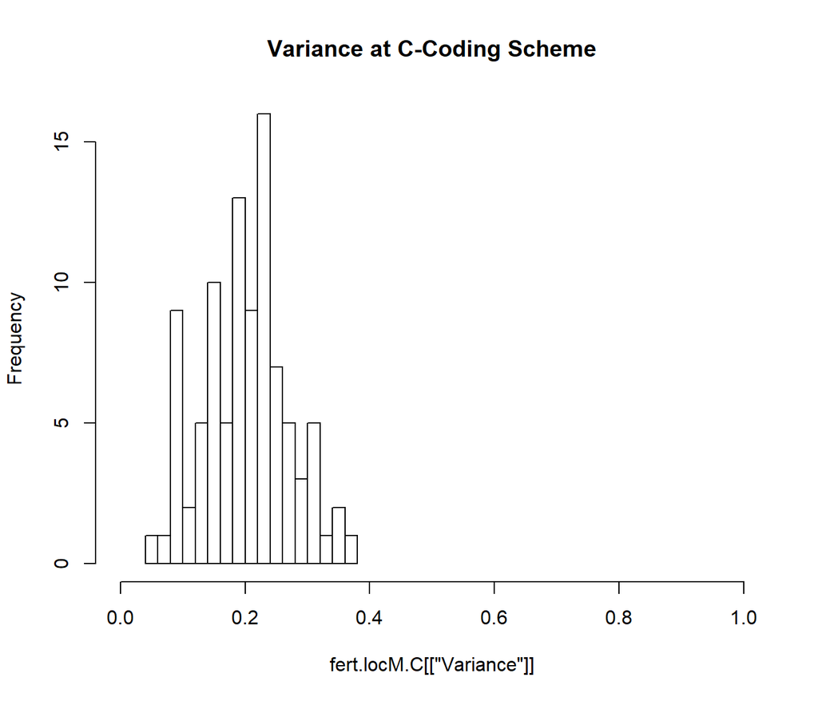

```r
##
## Compare the standard deviations of loc MI's variances
## The local Moran's I_i values can be mapped
##

## C-coding scheme
fert.locM.C <- summary(localmoran.sad(fert.wlm, prov.link, style="C", resfun=weighted.residuals,
                                     alternative="less", select=seq_along(prov.shp)))
hist(fert.locM.C[["Variance"]], breaks=12 ,xlim=c(0,1), main="Variance at C-Coding Scheme")
```

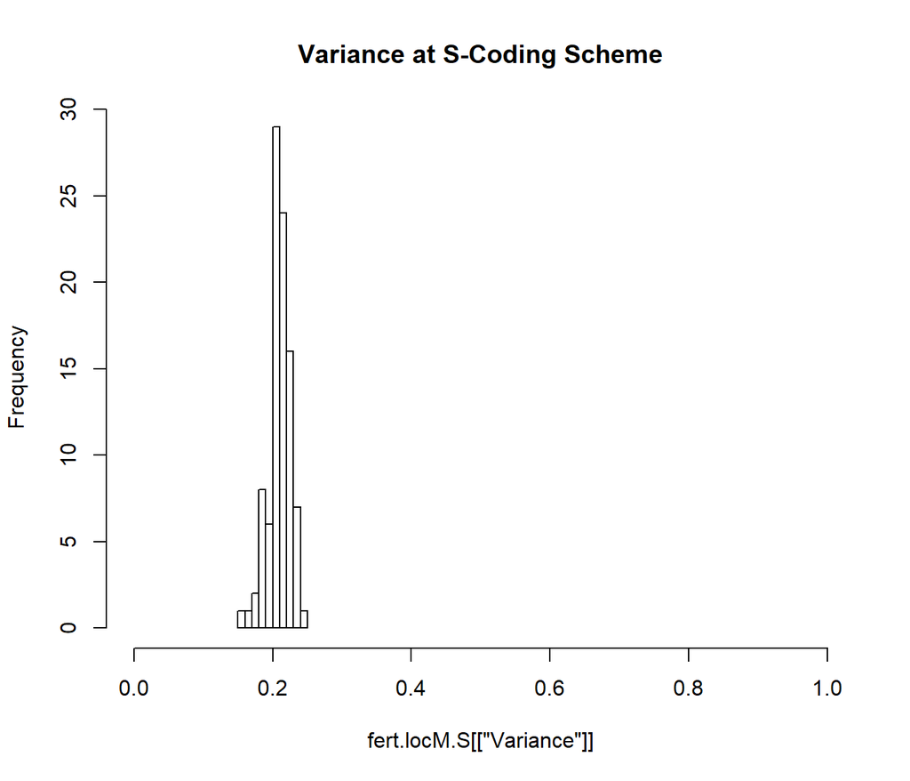

```r
## S-coding scheme
fert.locM.S <- summary(localmoran.sad(fert.wlm, prov.link, style="S", resfun=weighted.residuals,
                                     alternative="less", select=seq_along(prov.shp)))
hist(fert.locM.S[["Variance"]], breaks=12, xlim=c(0,1), main="Variance at S-Coding Scheme")
```

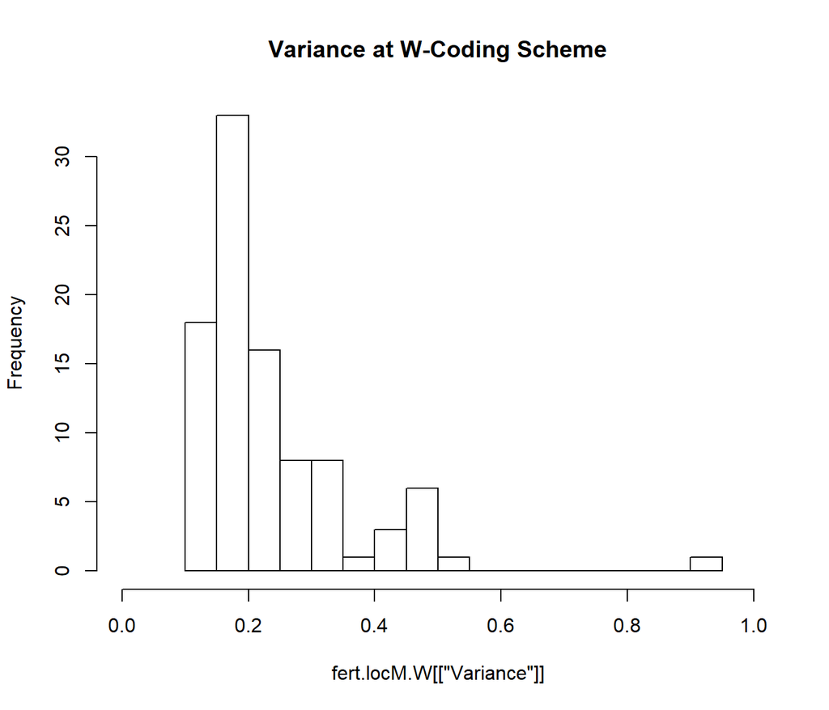

```r
## W-coding scheme
fert.locM.W <- summary(localmoran.sad(fert.wlm, prov.link, style="W", resfun=weighted.residuals,
                                     alternative="less", select=seq_along(prov.shp)))
hist(fert.locM.W[["Variance"]], breaks=12, xlim=c(0,1), main="Variance at W-Coding Scheme")
```